# ROCnReg: An R Package for Receiver Operating Characteristic Curve Inference With and Without Covariates

### 4.3 Covariate-adjusted ROC curve

In this section, we illustrate how to conduct inference about the covariate-adjusted ROC curve using *ROCnReg*. Similar to the covariate-specific ROC curve, three approaches are available for estimating the AROC curve. The function `AROC.bnp` is illustrated below, while `AROC.sp` and `AROC.kernel` are exemplified in the Supplementary Material.

Recall that the AROC curve is a global summary measure of diagnostic accuracy that takes covariate information into account. In the context of our endocrine application, we seek to study the overall discriminatory capacity of the BMI for detecting the presence of CVD risk factors when adjusting for age and gender. Here, we focus on how to estimate the AROC curve using the `AROC.bnp` function. The function syntax is exactly similar to the one of `cROC.bnp`, with the only difference being that we only need to specify the arguments related to the nondiseased population. The code and respective summary follow.

```r
R> set.seed(123, "L'Ecuyer-CMRG") # for reproducibility
R> AROC_bnp <- AROC.bnp(
+ formula.h = bmi ~ gender + f(age, by = gender, K = c(0,0))
+ group = "cvd_idf", tag.h = 0, data = endosyn, standardise = TRUE,
+ p = seq(0, 1, l = 101), ci.level = 0.95, compute.lpml = TRUE, compute.WAIC = TRUE,
+ compute.DIC = TRUE, pauc = pauccontrol(compute = FALSE),
+ prior.h = priorcontrol.bnp(L = 10), density = densitycontrol(compute = TRUE),
+ mcmc = mcmccontrol(nsave = 8000, nburn = 2000, nskip = 1),
+ parallel = "snow", ncpus = 2)

R> summary(AROC_bnp)

Call: [...]

Approach: AROC Bayesian nonparametric
----------------------------------------------
Area under the covariate-adjusted ROC curve: 0.656 (0.629, 0.684)*
 * Credible level:  0.95

Model selection criteria:
                     Group H
WAIC               11833.000
WAIC (Penalty)        31.236
LPML               -5916.766
DIC                11829.750
DIC (Penalty)         29.611


Sample sizes:
                           Group H     Group D
Number of observations        2149         691
Number of missing data           0           0
```

The area under the AROC curve is $0.656$ (95% credible interval: $(0.629, 0.684)$) thus revealing a reasonable good ability of the BMI to detect the presence of CVD risk factors when teasing out the age and gender effects. As for the pooled ROC curve and the covariate-specific ROC curve, a `plot` function is also available (result in Figure 11a).

```r
R> plot(AROC_bnp, cex.main = 1.5, cex.lab = 1.5, cex.axis = 1.5, cex = 1.3)
```

Finally, we compare the AROC curve with the pooled ROC curve that was obtained earlier by using a DPM model with 10 components in each group. In Figure 11b, we show the plots of the two curves, and, as can be noticed, the pooled ROC curve lies well above the AROC curve, thus evidencing the need for incorporating covariate information into the analysis.

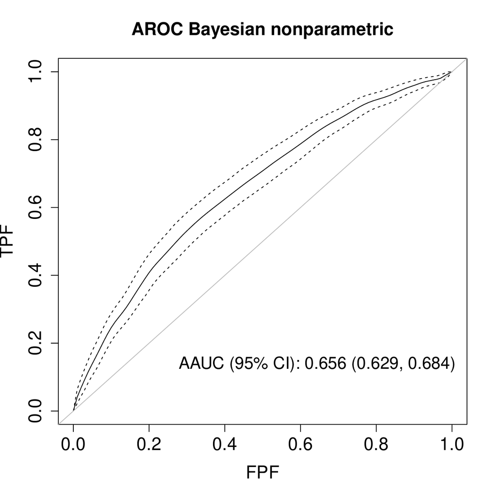

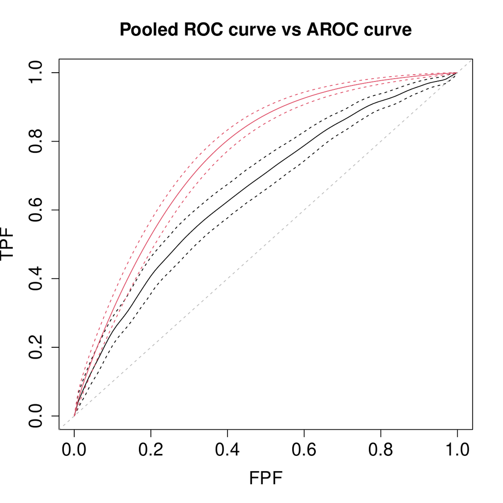

```r
R> plot(AROC_bnp$p, AROC_bnp$ROC[,1], type = "l", xlim = c(0,1), ylim = c(0,1),
+ xlab = "FPF", ylab = "TPF", main = "Pooled ROC curve vs AROC curve", cex.main = 1.5,
+ cex.lab = 1.5, cex.axis = 1.5, cex = 1.5)
R> lines(AROC_bnp$p, AROC_bnp$ROC[,2], col = 1, lty = 2)
R> lines(AROC_bnp$p, AROC_bnp$ROC[,3], col = 1, lty = 2)
R> lines(pROC_dpm$p, pROC_dpm$ROC[,1], col = 2)
R> lines(pROC_dpm$p, pROC_dpm$ROC[,2], col = 2, lty = 2)
R> lines(pROC_dpm$p, pROC_dpm$ROC[,3], col = 2, lty = 2)
R> abline(0, 1, col = "grey", lty = 2)
```

1. AROC curve
2. AROC vs Poooled ROC curve

Figure 11: (a) Age and gender-adjusted ROC curve: posterior mean and 95% pointwise credible band. (b) Age and gender-adjusted ROC curve (in black) and pooled ROC curve (estimated using a DPM of normals model) (in red). Solid lines represent the posterior means and dashed lines the 95% pointwise credible bands.

### 4.4 Computational aspects

We finish this section with some comments on computational aspects. In our experience, the methods with the largest computing times are those implemented in `cROC.bnp` when $L_{\bar{D}} > 1$ and in `cROC.kernel` when confidence bands are to be constructed. In the first case, the main reason behind the computational burden is the need to invert $F_{\bar{D}}\left(\cdot \mid \mathbf{x}\right)$ in order to obtain the covariate-specific ROC curve (see equation ((10))). Note that when $L_{\bar{D}}>1$, the conditional distribution function in the nondiseased group is given by a mixture of normal distributions, and the corresponding quantile function needs to be computed for each covariate(s) value we might be interested in and for each iteration of the Gibbs sampler procedure. Regarding the `cROC.kernel` function, the computing time is mainly driven by the number of bootstrap samples used for constructing the confidence bands. In Table 2, we show the time, in seconds, needed for fitting the pooled, the covariate-specific, and the covariate-adjusted ROC curve using the Bayesian nonparametric and the kernel approaches for the synthetic endocrine data and when both parallel (with 2 and 4 processes) and no parallel options are used. We note that for the Bayesian approaches, we also computed the densities/conditional densities, as well as the WAIC, LPML, and DIC, which further increase the computing time (in the case of the AROC curve, these were only computed in the nondiseased population). With respect to the kernel-based approach (in this case, the fit is done separately for men and women and the corresponding results are presented in the Supplementary Material), we have used $500$ bootstrap samples to construct the confidence bands. As it can be appreciated, for these two intense tasks, using 4 processes drastically improves the computation time. All computations were performed in a iMac with 3.6GHz quad core Intel i7 processor and 32GB RAM running under a macOS Catalina 10.15.5 operating system.

Table 2: Time in seconds (rounded to the nearest second) needed to fit the pooled, the covariate-specific, and the covariate-adjusted ROC curve for the Bayesian nonparametric and kernel approaches.

|  | No parallel | Snow (2 cores) | Snow (4 cores) |
| --- | --- | --- | --- |
| `pooledROC.dpm` | 138 | 118 | 111 |
| `pooledROC.kernel` | 376 | 196 | 105 |
| `cROC.bnp` | 2052 | 1117 | 680 |
| `cROC.kernel` | Men: 1159 | Men: 528 | Men: 279 |
|  | Women: 1885 | Women: 916 | Women: 466 |
| `AROC.bnp` | 126 | 115 | 112 |
| `AROC.kernel` | Men: 847 | Men: 404 | Men: 214 |
|  | Women: 1707 | Women: 833 | Women: 438 |

## 5 Summary and future plans

In this paper, we have introduced the capabilities of the R package *ROCnReg* for conducting inference about the pooled ROC curve, the covariate-specific ROC curve, and the covariate-adjusted ROC curve and their associated summary indices. As we have illustrated, the current version of the package provides several options for estimating ROC curves, both under frequentist and Bayesian paradigms, either parametrically, semiparametrically, or nonparametrically. To the best of our knowledge, this is the first software package implementing Bayesian inference for ROC curves. Several additions/extensions are planned in the future, and these, among others, include:

- Implement the most time-consuming parts in C or C++.
- Incorporate methods for non-binary disease status (e.g., no disease, mild disease, severe disease). That is, implement ROC surface models.
- Implement new (optimal) threshold criteria (e.g., YI including costs).

## 6 Computational details

The results in this paper were obtained using R 4.0.3 with the *ROCnReg* 1.0-5 package. The *ROCnReg* package has several dependencies: *graphics*, *grDevices*, *parallel*, *splines*, *stats*, [*moments*](https://CRAN.R-project.org/package=moments) (Komsta and Novomestky 2015), [*nor1mix*](https://CRAN.R-project.org/package=nor1mix) (Maechler 2019), [*Matrix*](https://CRAN.R-project.org/package=Matrix) (Bates and Maechler 2019), [*spatstat*](https://CRAN.R-project.org/package=spatstat) (Baddeley and Turner 2005), [*np*](https://CRAN.R-project.org/package=np) (Hayfield and Racine 2008), [*lattice*](https://CRAN.R-project.org/package=lattice) (Sarkar 2008), [*MASS*](https://CRAN.R-project.org/package=MASS) (Venables and Ripley 2002), and [*pbivnorm*](https://CRAN.R-project.org/package=pbivnorm) (Genz and Kenkel 2015). R itself and all packages used are available from the Comprehensive R Archive Network (CRAN) at https://CRAN.R-project.org/.

## 7 Acknowledgements

We acknowledge the reviewer for their constructive comments that led to an improved version of the article. MX Rodríguez-Álvarez was funded by project MTM2017-82379-R (AEI/FEDER, UE), by the Basque Government through the BERC 2018-2021 program and Elkartek project 3KIA (KK-2020/00049) and by the Spanish Ministry of Science, Innovation, and Universities (BCAM Severo Ochoa accreditation SEV-2017-0718).

### 7.1 Supplementary materials

Supplementary materials are available in addition to this article. It can be downloaded at RJ-2021-066.zip

### 7.2 CRAN packages used

sROC, pROC, nsROC, npROCRegression, OptimalCutpoints, ThresholdROC, ROCnReg, ggplot2, coda, moments, nor1mix, Matrix, spatstat, np, lattice, MASS, pbivnorm

### 7.3 CRAN Task Views implied by cited packages

Bayesian, ChemPhys, Cluster, Distributions, Econometrics, Environmetrics, GraphicalModels, MixedModels, NetworkAnalysis, NumericalMathematics, Phylogenetics, Psychometrics, Robust, Spatial, SpatioTemporal, Survival, TeachingStatistics

A. Baddeley and R. Turner. spatstat: An R package for analyzing spatial point patterns. *Journal of Statistical Software*, 12(6): 1–42, 2005. URL http://doi.org/10.18637/jss.v012.i06.

D. Bates and M. Maechler. *Matrix: Sparse and dense matrix classes and methods.* 2019. URL https://CRAN.R-project.org/package=Matrix. R package version 1.2-18.

G. Celeux, F. Forbes, C. P. Robert and D. M. Titterington. Deviance information criteria for missing data models. *Bayesian Analysis*, 1(4): 651–673, 2006. URL https://doi.org/10.1214/06-BA122.

M. De Iorio, W. O. Johnson, P. Müller and G. L. Rosner. Bayesian nonparametric nonproportional hazards survival modeling. *Biometrics*, 65(3): 762–771, 2009. URL https://doi.org/10.1111/j.1541-0420.2008.01166.x.

A. Erkanli, M. Sung, E. Jane Costello and A. Angold. Bayesian semi-parametric ROC analysis. *Statistics in Medicine*, 25(22): 3905–3928, 2006. URL https://doi.org/10.1002/sim.2496.

D. Faraggi. Adjusting receiver operating characteristic curves and related indices for covariates. *Journal of the Royal Statistical Society D*, 52(2): 179–192, 2003. URL https://doi.org/10.1111/1467-9884.00350.

T. S. Ferguson. A Bayesian analysis of some nonparametric problems. *The Annals of Statistics*, 1(2): 209–230, 1973. URL https://doi.org/10.1214/aos/1176342360.

J. Gabry, D. Simpson, A. Vehtari, M. Betancourt and A. Gelman. Visualization in Bayesian workflow. *Journal of the Royal Statistical Society A*, 182(2): 389–402, 2019. URL https://doi.org/10.1111/rssa.12378.

S. Geisser and W. F. Eddy. A predictive approach to model selection. *Journal of the American Statistical Association*, 74(365): 153–160, 1979. URL https://doi.org/10.2307/2286745.

A. Gelman, J. B. Carlin, H. S. Stern, D. B. Dunson, A. Vehtari and D. B. Rubin. *Bayesian data analysis.* Third Chapman; Hall/CRC, 2013.

A. Gelman, J. Hwang and A. Vehtari. Understanding predictive information criteria for Bayesian models. *Statistics and Computing*, 24(6): 997–1016, 2014. URL https://doi.org/10.1007/s11222-013-9416-2.

A. Genz and B. Kenkel. *Pbivnorm: Vectorized bivariate normal CDF.* 2015. URL https://CRAN.R-project.org/package=pbivnorm. R package version 0.6.0.

J. Gu, S. Ghosal and A. Roy. Bayesian bootstrap estimation of ROC curve. *Statistics in Medicine*, 27: 5407–5420, 2008. URL https://doi.org/10.1002/sim.3366.

Z. Guan, J. Qin and B. Zhang. Information borrowing methods for covariate-adjusted ROC curve. *Canadian Journal of Statistics*, 40(3): 569–587, 2012. URL https://doi.org/10.1002/cjs.11145.

T. Hayfield and J. S. Racine. Nonparametric econometrics: The np package. *Journal of Statistical Software*, 27(5): 2008. URL https://doi.org/10.18637/jss.v027.i05.

S. L. Hillis and C. E. Metz. An analytic expression for the binormal partial area under the ROC curve. *Academic Radiology*, 19(12): 1491–1498, 2012. URL https://doi.org/10.1016/j.acra.2012.09.009.

F. Hsieh and B. W. Turnbull. Nonparametric and semiparametric estimation of the receiver operating characteristic curve. *The Annals of Statistics*, 24(1): 25–40, 1996. URL https://doi.org/10.1214/aos/1033066197.

V. Inácio de Carvalho, M. de Carvalho and A. J. Branscum. Nonparametric Bayesian covariate-adjusted estimation of the Youden index. *Biometrics*, 73(4): 1279–1288, 2017. URL https://doi.org/10.1111/biom.12686.

V. Inácio de Carvalho, A. Jara, T. E. Hanson and M. de Carvalho. Bayesian nonparametric ROC regression modeling. *Bayesian Analysis*, 8(3): 623–646, 2013. URL https://doi.org/10.1214/13-BA825.

V. Inácio de Carvalho and M. X. Rodríguez-Álvarez. Bayesian nonparametric inference for the covariate-adjusted ROC curve. *arXiv:1806.00473 [stat.ME]*, 2018. URL https://arxiv.org/abs/1806.00473.

V. Inácio, M. X. Rodrı́guez-Álvarez and P. Gayoso-Diz. Statistical evaluation of medical tests. *Annual Review of Statistics and Its Application*, 8: 2020. URL https://doi.org/10.1146/annurev-statistics-040720-022432.

H. Ishwaran and L. F. James. Approximate Dirichlet process computing in finite normal mixtures: Smoothing and prior information. *Journal of Computational and Graphical Statistics*, 11(3): 508–532, 2002. URL https://doi.org/10.1198/106186002411.

H. Ishwaran and L. F. James. Gibbs sampling methods for stick-breaking priors. *Journal of the American Statistical Association*, 96(453): 161–173, 2001. URL https://doi.org/10.1198/016214501750332758.

H. Janes and M. S. Pepe. Adjusting for covariate effects on classification accuracy using the covariate-adjusted receiver operating characteristic curve. *Biometrika*, 96(2): 371–382, 2009. URL https://doi.org/10.1093/biomet/asp002.

L. Komsta and F. Novomestky. *Moments: Moments, cumulants, skewness, kurtosis and related tests.* 2015. URL https://CRAN.R-project.org/package=moments. R package version 0.14.

M. López-Ratón, M. X. Rodrı́guez-Álvarez, C. Cadarso-Suárez and F. Gude-Sampedro. OptimalCutpoints: An R package for selecting optimal cutpoints in diagnostic tests. *Journal of Statistical Software*, 61(8): 1–36, 2014. URL https://doi.org/10.18637/jss.v061.i08.

S. N. MacEachern. Dependent Dirichlet processes. *Unpublished manuscript, Department of Statistics, The Ohio State University*, 1–40, 2000.

M. Maechler. *nor1mix: Normal aka gaussian (1-d) mixture models (S3 classes and methods).* 2019. URL https://CRAN.R-project.org/package=nor1mix. R package version 1.3-0.

C. E. Metz. Basic principles of ROC analysis. *Seminars in Nuclear Medicine*, 8(4): 283–298, 1978. URL https://doi.org/10.1016/S0001-2998(78)80014-2.

J. C. Pardo-Fernández, M. X. Rodríguez-Álvarez and I. van Keilegom. A review on ROC curves in the presence of covariates. *REVSTAT–Statistical Journal*, 12(1): 21–41, 2014.

M. S. Pepe. *The statistical evaluation of medical tests for classification and prediction.* Oxford University Press, New York, 2003.

M. S. Pepe. Three approaches to regression analysis of receiver operating characteristic curves for continuous test results. *Biometrics*, 54(1): 124–135, 1998. URL https://doi.org/10.2307/2534001.

S. Perez Jaume, K. Skaltsa, N. Pallarès and J. L. Carrasco. ThresholdROC: Optimum threshold estimation tools for continuous diagnostic tests in R. *Journal of Statistical Software*, 82(4): 1–21, 2017. URL https://doi.org/10.18637/jss.v082.i04.

S. Pérez Fernández, P. Martı́nez Camblor, P. Filzmoser and N. Corral Blanco. NsROC: An R package for non-standard ROC curve analysis. *The R Journal*, 10(2): 2018. URL https://doi.org/10.32614/RJ-2018-043.

M. Plummer, N. Best, K. Cowles and K. Vines. CODA: Convergence diagnosis and output analysis for MCMC. *R News*, 6(1): 7–11, 2006. URL https://journal.r-project.org/archive/.

X. Robin, N. Turck, A. Hainard, N. Tiberti, F. Lisacek, J.-C. Sanchez and M. Müller. pROC: An open-source package for R and S+ to analyze and compare ROC curves. *BMC Bioinformatics*, 12: 77, 2011. URL https://doi.org/10.1186/1471-2105-12-77.

M. X. Rodriguez-Alvarez and J. Roca-Pardinas. *npROCRegression: Kernel-based nonparametric ROC regression modelling.* 2017. URL https://CRAN.R-project.org/package=npROCRegression. R package version 1.0-5.

M. X. Rodríguez-Álvarez, J. Roca-Pardiñas and C. Cadarso-Suárez. A new flexible direct ROC regression model: Application to the detection of cardiovascular risk factors by anthropometric measures. *Computational Statistics & Data Analysis*, 55(12): 3257–3270, 2011a. URL https://doi.org/10.1016/j.csda.2011.06.008.

M. X. Rodríguez-Álvarez, J. Roca-Pardiñas and C. Cadarso-Suárez. ROC curve and covariates: Extending induced methodology to the non-parametric framework. *Statistics and Computing*, 21(4): 483–499, 2011b. URL https://doi.org/10.1007/s11222-010-9184-1.

M. X. Rodríguez-Álvarez, P. G. Tahoces, C. Cadarso-Suárez and M. J. Lado. Comparative study of ROC regression techniques – applications for the computer-aided diagnostic system in breast cancer detection. *Computational Statistics & Data Analysis*, 55(1): 888–902, 2011c. URL https://doi.org/10.1016/j.csda.2010.07.018.

P. S. Rosenberg. Hazard function estimation using B-splines. *Biometrics*, 51(3): 874–887, 1995. URL https://doi.org/10.2307/2532989.

D. Sarkar. *Lattice: Multivariate data visualization with r.* New York: Springer-Verlag, 2008. URL http://lmdvr.r-forge.r-project.org. ISBN 978-0-387-75968-5.

D. E. Shapiro. The interpretation of diagnostic tests. *Statistical Methods in Medical Research*, 8(2): 113–134, 1999. URL https://doi.org/10.1016/s0004-9514(14)60228-2.

M. A. Tomé Martínez de Rituerto, M. A. Botana, C. Cadarso-Suárez, A. Rego-Iraeta, A. Fernández-Mariño, J. A. Mato, I. Solache and R. Perez-Fernandez. Prevalence of metabolic syndrome in Galicia (NW Spain) on four alternative definitions and association with insulin resistance. *Journal of Endocrinological Investigation*, 32(6): 505–511, 2009. URL https://doi.org/10.1007/BF03346497.

W. N. Venables and B. D. Ripley. *Modern applied statistics with s.* Fourth New York: Springer, 2002. URL http://www.stats.ox.ac.uk/pub/MASS4. ISBN 0-387-95457-0.

X.-F. Wang. *sROC: Nonparametric smooth ROC curves for continuous data.* 2012. URL https://CRAN.R-project.org/package=sROC. R package version 0.1-2.

H. Wickham. *ggplot2: Elegant graphics for data analysis.* Springer-Verlag New York, 2016. URL https://ggplot2.tidyverse.org.

W. J. Youden. Index for rating diagnostic tests. *Cancer*, 3(1): 32–35, 1950. URL https://doi.org/10.1002/1097-0142(1950)3:1<32::AID-CNCR2820030106>3.0.CO;2-3.

X.-H. Zhou, D. K. McClish and N. A. Obuchowski. *Statistical methods in diagnostic medicine.* Second John Wiley & Sons, New York, 2011.

K. H. Zou, W. J. Hall and D. E. Shapiro. Smooth non-parametric receiver operating characteristic (ROC) curves for continuous diagnostic tests. *Statistics in Medicine*, 16(19): 2143–2156, 1997. URL https://doi.org/10.1002/(sici)1097-0258(19971015)16:19<2143::aid-sim655>3.0.co;2-3 .